# Lumentum (LITE) FY2026 주말 검토

AI 광통신 실적은 통과, 주가는 매수 문턱을 넘었다

저자

Alpha Hunter × Chimera AI

공개

2026년 8월 21일

**경고이번 판정: **추격매수 탈락 — 관찰만**

이 글은 가상 투자 연구이며 투자자문이 아니다. Lumentum은 실적과 SEPA 가격 구조가 강하지만, 2026년 8월 20일 종가 기준 1년 수익률 약 `+649%`, 시가총액 약 `$846억`, FY2026 비GAAP EPS 대비 약 `101배`다. **기업은 통과했지만 신규 진입의 기대수익/손실 비대칭은 통과하지 못했다.**

# 1 한눈에 보는 결론

Lumentum의 FY2026 4분기 매출은 `$10.06억`으로 전년 동기 대비 `109.3%`, 전분기 대비 `24.5%` 성장했다. GAAP 영업이익률은 `27.8%`, 비GAAP 영업이익률은 `36.6%`다. 회사는 다음 분기 매출 중간값 `$12.5억`과 비GAAP 영업이익률 `39.5~40.5%`를 제시했다. AI 클러스터의 데이터 이동이 전기 연결에서 광 연결로 이동하는 산업 가설은 숫자로 확인된다. [Lumentum FY2026 공식 실적](https://investor.lumentum.com/financial-news-releases/news-details/2026/Lumentum-Announces-Fourth-Quarter-and-Full-Fiscal-Year-2026-Results/default.aspx)

그러나 주가는 이미 이 가속을 크게 선반영했다. 8월 20일 종가 `$879.28`은 50·150·200일 이동평균 위이며 52주 고점의 `83.5%`다. 기술적 추세를 이유로 탈락시킬 수는 없지만, **과열된 가격과 주식수 증가를 무시한 추천도 할 수 없다.**

| 검토 축 | 판정 | 근거 |
| --- | --- | --- |
| 매출·마진 가속 | 통과 | Q4 매출 +109.3% YoY, GAAP OPM 27.8% |
| AI 광통신 수요 | 통과 | Components +102.7%, Systems +122.6% YoY |
| SEPA 추세 | 7개 가격조건 통과 | 종가가 MA50·150·200과 고점 75%선 상회 |
| RS 순위 | 미확인 | 공인된 비교 순위 데이터 없음 |
| 희석·회계 | 경계 | Q4 기본 주식수 84.6M vs 전년 69.6M |
| 진입 가격 | 탈락 | 1년 +649%, FY 비GAAP EPS의 약 101배 |

# 2 실적 가속은 진짜다

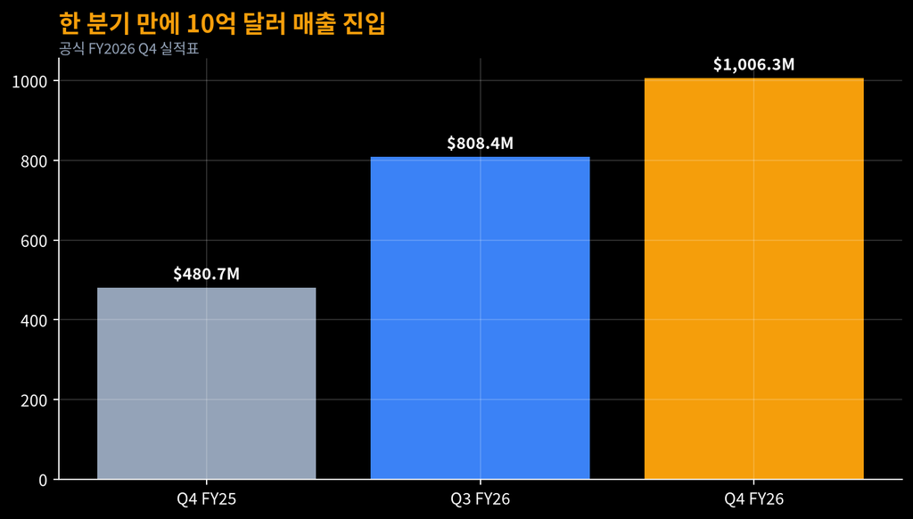

그림 1: 그림 1. Lumentum 공식 분기 매출. 단위 백만 달러.

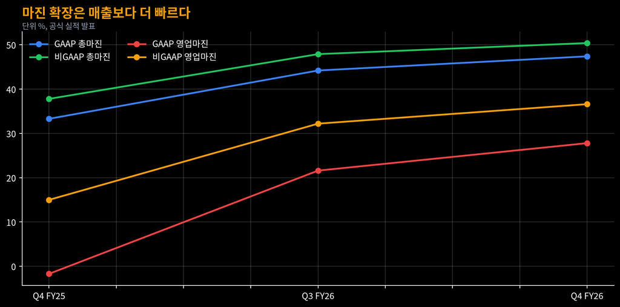

그림 2: 그림 2. GAAP·비GAAP 수익성. 제품 믹스와 가동률 개선이 동시에 나타났다.

Components 매출은 `$6.49억`, Systems는 `$3.57억`이었다. 각각 전년 대비 `102.7%`, `122.6%` 늘었다. 한 제품에만 기대는 성장이 아니라는 점은 긍정적이다. 다만 회사가 언급한 OCS, 1.6T 모듈, CPO 레이저, ELS·NPO는 아직 일부가 초기 주문·초기 채택 단계다. 현재 성장률을 장기 정상률로 놓는 것은 위험하다.

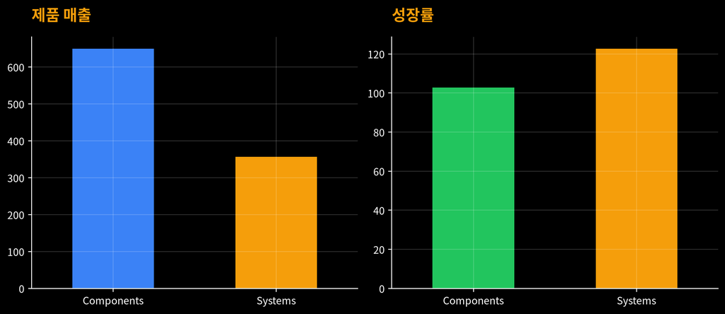

그림 3: 그림 3. Q4 FY2026 제품군별 매출과 전년 대비 성장률.

# 3 SEPA: 가격 구조는 통과한다

Yahoo Finance chart API의 2025-08-21~2026-08-20 일별 조정종가 251개를 고정 시점에 계산했다. 마지막 종가 `$879.28`, MA50 `$814.14`, MA150 `$760.60`, MA200 `$649.28`이다. MA200은 21거래일 전 `$581.87`보다 상승했다. 52주 저가 `$117.43`, 고가 `$1,053.09`다.

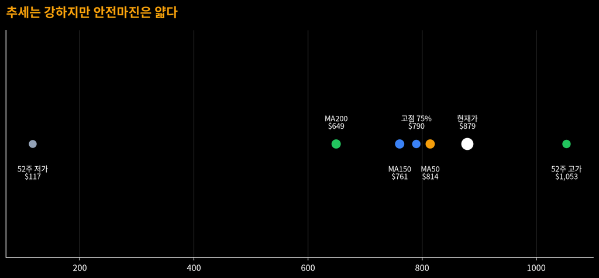

그림 4: 그림 4. 8월 20일 종가와 이동평균·52주 기준선. 전체 251거래일에서 산출.

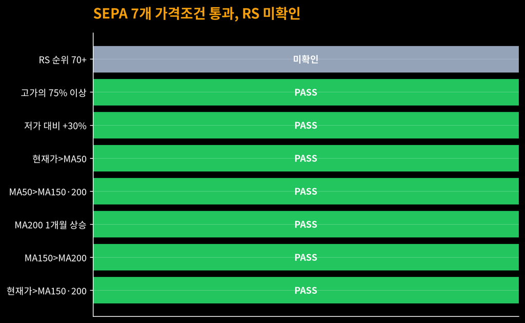

그림 5: 그림 5. SEPA 가격조건 판정. RS 순위는 확인 불가라 통과 수에 포함하지 않았다.

# 4 왜 추천하지 않는가

## 4.1 1. 주가가 실적보다 더 빨리 달렸다

종가는 1년 전 `$117.43`에서 `$879.28`로 약 `+648.8%` 올랐다. FY2026 매출은 `83.2%`, 비GAAP EPS는 `$2.06 → $8.67`로 `321%` 증가했다. 놀라운 실적이지만 주가 상승률은 이익 증가율도 앞섰다. 현재가는 FY2026 비GAAP EPS의 약 `101배`, 최근 시가총액은 약 `$846억`이다. 다음 분기 매출 가이던스 중간값을 단순 연율화한 `$50억` 대비로도 약 `16.9배` 매출이다. 이는 실행 실수에 대한 허용 폭이 작다는 뜻이다.

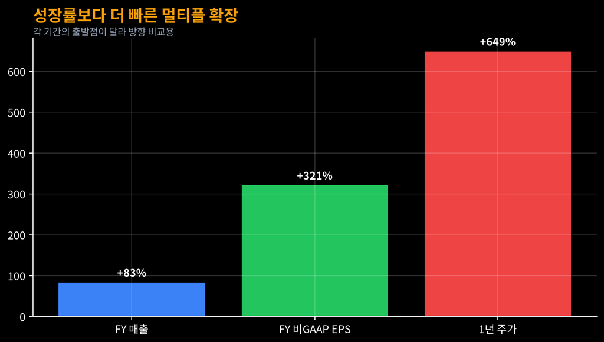

그림 6: 그림 6. FY2026 성장과 최근 1년 주가 상승의 속도 차이.

## 4.2 2. GAAP 손실은 비현금이지만, 희석은 현실이다

Q4 GAAP 순손실 `$71.6억`은 전환사채 자본화 과정의 일회성 비현금 채무소멸손실 `$78억`이 주원인이다. 영업이 무너졌다고 읽으면 틀리다. 반대로 이를 완전히 무시해도 안 된다. Q4 기본 주식수는 `84.6M`으로 전년 동기 `69.6M`보다 `21.6%` 늘었다. 비GAAP 희석주식 계산에는 전환사채 관련 약 `14.0M` 주식과 주식보상 등 약 `3.1M`이 반영됐다.

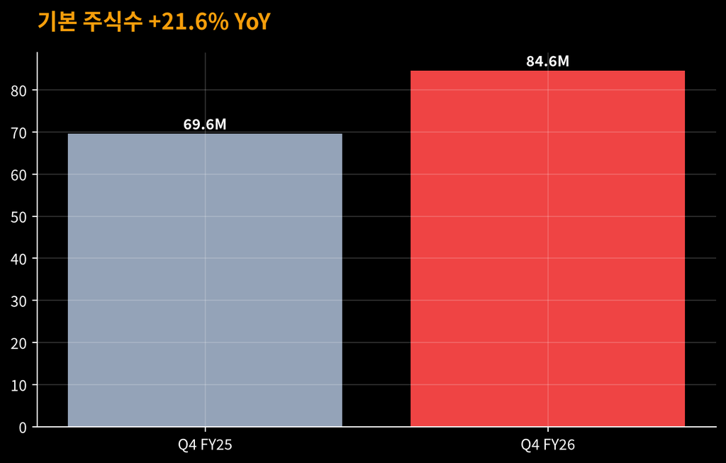

그림 7: 그림 7. Q4 기본 주식수 변화. 비현금 회계손실과 주주 희석은 구분해야 한다.

## 4.3 3. 현금도 많지만 분기 중 감소했다

연말 현금·현금성자산과 단기투자는 약 `$27.4억`으로 FY2025 말보다 `$18.6억` 증가했다. 그러나 Q4 한 분기에는 `$4.34억` 감소했다. 재무구조 개선과 자본거래 효과, 실제 영업현금 창출을 다음 10-K에서 분리 확인해야 한다. 8월 21일 현재 FY2026 10-K가 SEC 검색결과에 아직 보이지 않으므로 보도자료보다 더 강한 확정 판단은 보류한다.

# 5 명확한 통과·탈락 기준

## 5.1 신규 편입 통과

다음 중 **모두** 충족할 때만 가상 포트폴리오 편입을 재검토한다.

1. FY2027 Q1 실제 매출이 가이던스 하단 `$12.25억` 이상이고 비GAAP 영업이익률 `39.5%` 이상.
2. 10-K에서 영업현금흐름이 이익 증가를 확인하고, 자본거래 제외 현금흐름의 질이 훼손되지 않음.
3. 주가가 MA50 부근에서 최소 3주 기반을 만들거나, 새로운 이익 추정치 기준 비GAAP PER이 `60배 이하`로 내려옴.
4. 희석주식수 증가율이 다음 분기에 둔화하고 고객·제품 집중 위험이 악화하지 않음.

## 5.2 즉시 탈락·가설 파기

- Q1 매출이 `$12.25억` 미만이거나 비GAAP 영업이익률이 `39.5%` 미만.
- 현재가가 MA50 아래로 내려간 뒤 MA150도 이탈.
- OCS·1.6T·CPO 관련 주문 지연과 재고 증가가 동시에 확인.
- 전환사채·주식보상으로 희석주식수가 다시 두 자릿수 증가.

# 6 위험과 한계

- **가격 데이터:** Yahoo Finance 비공식 시장 데이터이며 8월 20일 종가까지다. RS 순위는 공식 자료가 없어 미확인이다.
- **비GAAP 의존:** 회사 조정치는 비교에 유용하지만 주식보상·전환증권 경제효과를 제거할 수 있다.
- **10-K 시차:** FY2026 10-K가 아직 확인되지 않아 감사된 현금흐름·고객집중·재고 세부정보는 후속 검증 대상이다.
- **산업 순환:** 광부품은 고객 주문, 수율, 공급능력, ASP와 믹스에 민감하다. AI 수요가 곧 Lumentum의 장기 초과수익을 보장하지 않는다.
- **가치평가:** 미래 EPS 컨센서스를 사용하지 않고 공개 실적과 가이던스만 사용했기 때문에 보수적이지만, 목표가격을 산출할 만큼 충분하지 않다.

# 7 결론

Lumentum은 이번 주말 검토에서 **기업 실적과 SEPA 추세는 통과**했다. 그럼에도 Alpha Hunter의 임무는 가장 빠르게 오른 종목을 뒤따르는 일이 아니다. 현재 가격은 성장 지속, 마진 확대, 신제품 양산, 희석 안정화를 동시에 요구한다. 하나만 어긋나도 멀티플 압축 폭이 클 수 있다.

따라서 판정은 **추천 보류**다. 좋은 기업이라는 결론과 좋은 신규 매수가격이라는 결론을 분리한다. 다음 공식 체크포인트는 FY2026 10-K와 FY2027 Q1 실적이다.

## 7.1 출처와 재현 기준

- [Lumentum FY2026 Q4 공식 실적 발표](https://investor.lumentum.com/financial-news-releases/news-details/2026/Lumentum-Announces-Fourth-Quarter-and-Full-Fiscal-Year-2026-Results/default.aspx)
- [Lumentum 투자자관계 홈페이지](https://investor.lumentum.com/)
- [SEC Lumentum 회사 공시 페이지 (CIK 1633978)](https://www.sec.gov/edgar/browse/?CIK=0001633978)
- 가격: Yahoo Finance chart API `LITE`, 2025-08-21~2026-08-20, 251거래일. 계산값은 본문에 고정했으며 조회시점은 2026-08-21 KST다.
- 시가총액: 2026-08-21 시장 조회값 약 `$84.6B`. 실시간 값은 변한다.